# Tema 7. Reconstrucción filogenética

# Los datos

## Distancias

Si comparamos 15 organismos entre ellos, podemos obtener una matriz de diferencias o **distancias** entre ellos, independientemente de las características que comparemos.

## Dos tipos de matrices

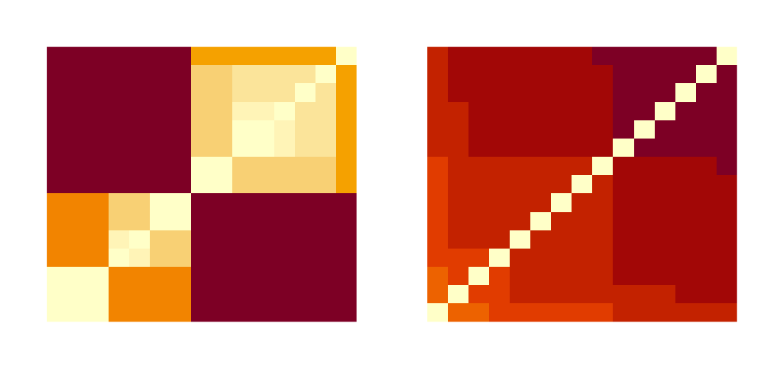

## Distancias

### Orígenes independientes

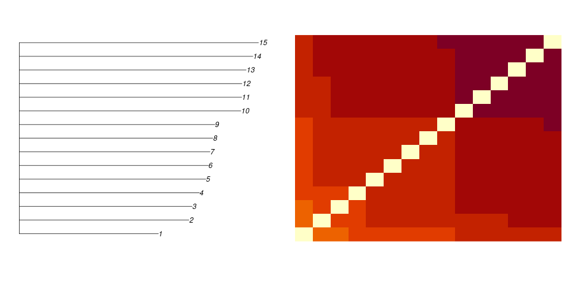

## Distancias

### Origen común

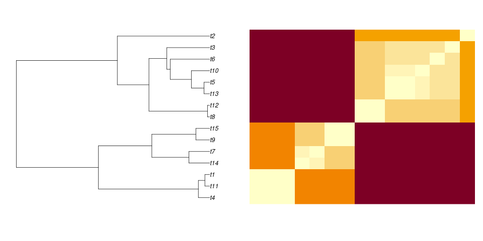

## Algunas conclusiones

1. Lo que observamos son diferencias.
2. La estructura de las matrices de diferencias sugieren un modelo.
3. El modelo o hipótesis es una genealogía o árbol filogenético.
4. No todas las matrices se ajustan igual de bien a ese modelo.

## Alineamiento

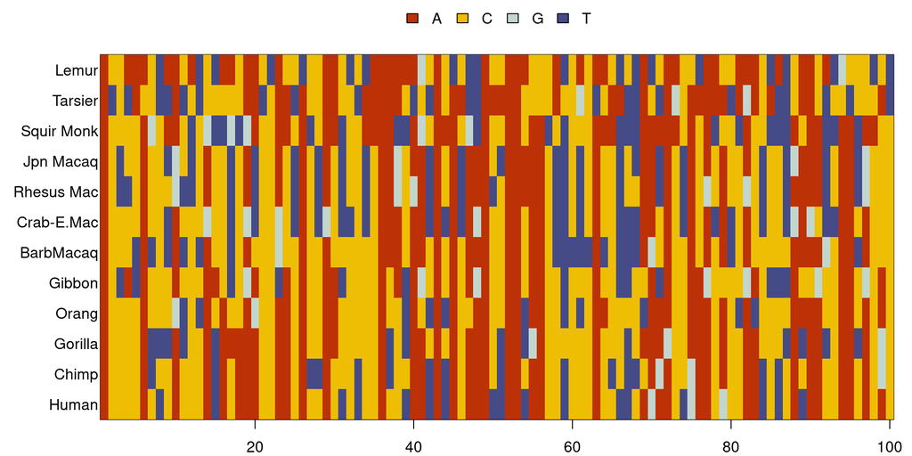

## Alineamientos

1. Nucleótidos o aminoácidos (pero nos centraremos en nucleótidos).
2. Cada posición es un carácter que puede haber cambiado o no.
3. No todas las posiciones son igual de variables.

# El modelo

## Los árboles

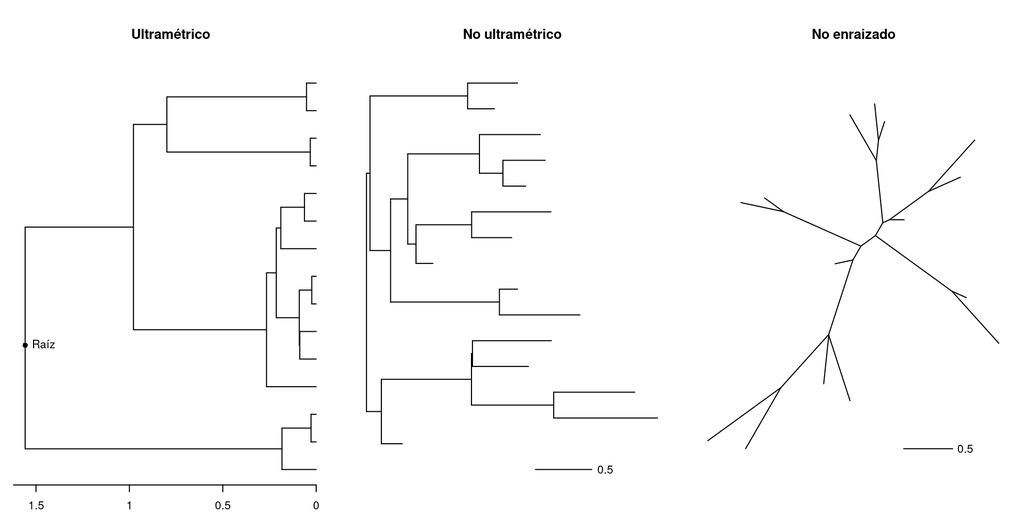

## Los árboles

1. La *topología* del árbol que relaciona las secuencias es un *parámetro* del modelo.
2. Las longitudes de las ramas también son parámetros a estimar.
3. ¿Cómo evolucionan las secuencias a lo largo del árbol? Modelo de evolución molecular.

## Cadena de Markov

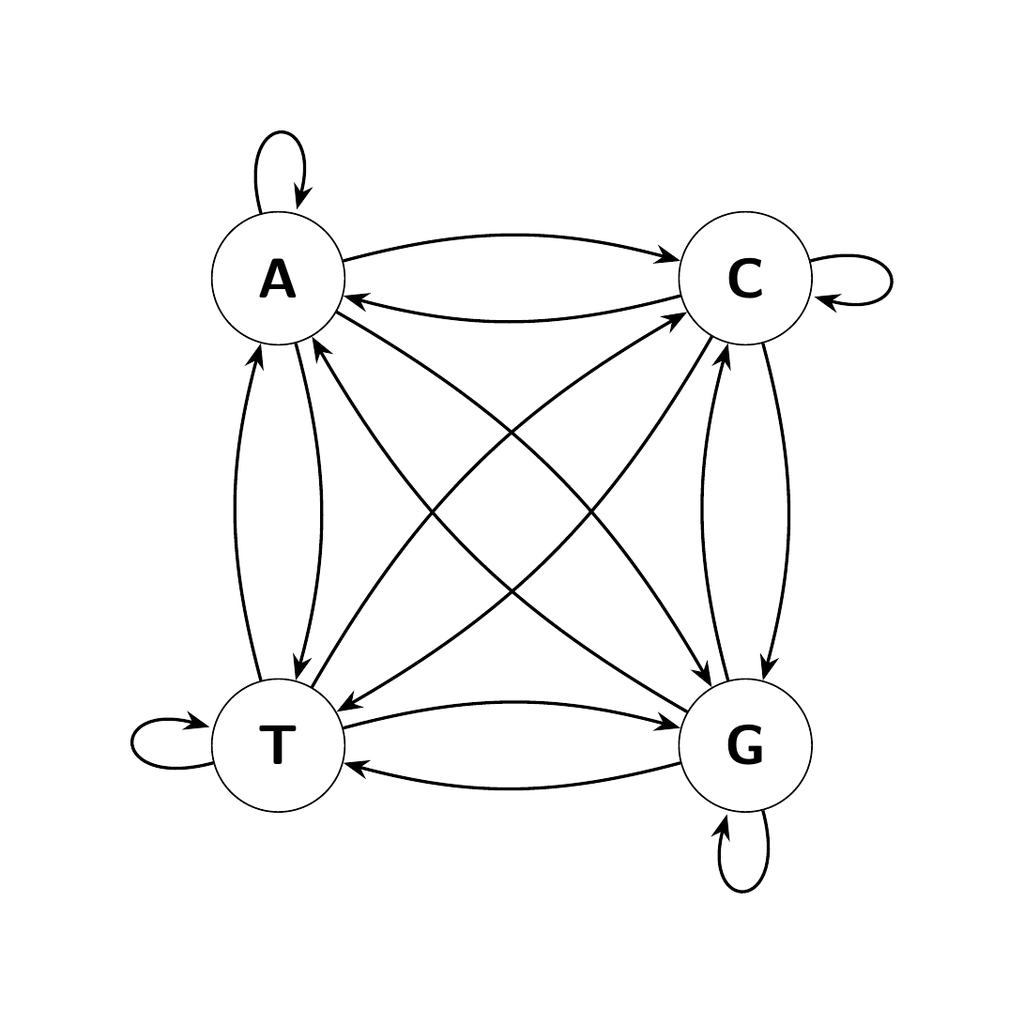

### Matriz de transición

$$P(t) = {\begin{pmatrix}
p_{AA}(t) & p_{AG}(t) & p_{AC}(t) & p_{AT}(t) \\
p_{GA}(t) & p_{GG}(t) & p_{GC}(t) & p_{GT}(t) \\
p_{CA}(t) & p_{CG}(t) & p_{CC}(t) & p_{CT}(t) \\
p_{TA}(t) & p_{TG}(t) & p_{TC}(t) & p_{TT}(t)
\end{pmatrix} }$$

Probabilidades de pasar de una base a otra en un tiempo *t*.

## Cadenas de Markov

Una cadena de Markov es una sucesión estocástica entre un número finito de estados, de manera que las probabilidades de transición sólo dependen del estado inmediatamente anterior.

Los modelos de evolución molecular usan *tiempo continuo*. $p_{ij}(t)$ es la probabilidad de que el resíduo *i* se convierta en *j* al cabo de un tiempo *t*, teniendo en cuenta *todos* los caminos posibles o mutaciones intermedias.

## Tasas de cambio

Después de un pequeño intervalo de tiempo $\Delta t$, la probabilidad de encontrar una adenina (A) en una posición de la secuencia será:

$$p_A(t + \Delta t) = p_A(t) - p_A(t)\mu_A \Delta t + \sum_{x\neq A}p_x(t)\mu_{xA}\Delta t$$
donde $\mu_A$ es la tasa a la que A se convierte en cualquier otra base, y $\mu_{xA}$ son las tasas a las que C, G y T se convierten en A.

## Matriz de tasas

$$\mathbf{p}(t+\Delta t) = \mathbf{p}(t) + \mathbf{p}Q\Delta t$$

$$Q = {\begin{pmatrix}
-\mu_A & \mu_{AG} & \mu_{AC} & \mu_{AT} \\
\mu_{GA} & -\mu_G & \mu_{GC} & \mu_{GT} \\
\mu_{CA} & \mu_{CG} & -\mu_C & \mu_{CT} \\
\mu_{TA} & \mu_{TG} & \mu_{TC} & -\mu_T
\end{pmatrix}}$$

$Q$ expresa la tasa de cambio instantáneo de unos nucleótidos a otros.

## Relación entre tasas y probabilidades

Suponemos que $Q$ no cambia con el tiempo (proceso estacionario). La matriz de transición $P(t)$ es la solución a la ecuación diferencial:

$$\frac{\mathrm{d}P(t)}{\mathrm{d}t} = P(t)Q$$

Con la condición $P(0) = I$, la matriz identidad (sin evolución, todo queda igual), se puede demostrar que:

$$P(t) = e^{tQ}$$

## Distribución estacionaria $\mathbf{\pi}$

La teoría predice que a lo largo de la evolución llega un momento a partir del cual las proporciones de los nucleótidos se mantienen estables.

**Composición nucleotídica de equilibrio**: $\boldsymbol{\pi} = (\pi_A, \pi_G, \pi_C, \pi_T)$.

$$\boldsymbol{\pi}Q = 0$$

## Reversibilidad temporal

El proceso de mutación es *reversible temporalmente* si la cantidad de cambio en un sentido es idéntica a la del sentido contrario, en el estado estacionario: $\pi_x \mu_{xy} = \pi_y \mu_{yx}$. Entonces:

$$\frac{\mu_{xy}}{\pi_y} = \frac{\mu_{yx}}{\pi_x} = s_{xy} = s_{yx}$$

Donde $s_{xy}$ o $s_{yx}$ se denomina *intercambiabilidad* entre $x$ e $y$. Entonces, 9 parámetros són suficientes para determinar $Q$: seis intercambiabilidades y 3 frecuencias estacionarias $\pi_x$.

## Unidades de tiempo

La matriz $Q$ expresa las frecuencias relativas de diferentes mutaciones. Pero la escala depende de las unidades de tiempo. Resulta conveniente normalizar $Q$ para que la tasa total de cambio ($R$) sea igual a 1.

$$R = \sum_i \pi_i |\mu_i| \\
Q^* = \frac{1}{R}Q$$

Así, una unidad de tiempo $t$ equivale a la cantidad de tiempo necesaria para que en término medio se produzca una sustitución por posición.

## Modelo de Jukes Cantor

$$\pi_A = \pi_G = \pi_C = \pi_T = \frac{1}{4}$$

$$Q = {\begin{pmatrix}
-3\alpha & \alpha & \alpha & \alpha \\
\alpha & -3\alpha & \alpha & \alpha \\
\alpha & \alpha & -3\alpha & \alpha \\
\alpha & \alpha & \alpha & -3\alpha
\end{pmatrix}}$$

## Modelo de Jukes Cantor

$$R = 3\alpha \\
Q^* = \frac{1}{R}Q = {\begin{pmatrix}
-1 & \frac{1}{3} & \frac{1}{3} & \frac{1}{3} \\
\frac{1}{3} & -1 & \frac{1}{3} & \frac{1}{3} \\
\frac{1}{3} & \frac{1}{3} & -1 & \frac{1}{3} \\
\frac{1}{3} & \frac{1}{3} & \frac{1}{3} & -1
\end{pmatrix}}$$

## Modelo de Jukes Cantor

$$P(t) = {\begin{pmatrix}
\frac{1}{4} + \frac{3}{4}e^{-4\alpha t} & \frac{1}{4} - \frac{1}{4}e^{-4\alpha t} & \frac{1}{4} - \frac{1}{4}e^{-4\alpha t} & \frac{1}{4} - \frac{1}{4}e^{-4\alpha t} \\
\frac{1}{4} - \frac{1}{4}e^{-4\alpha t} & \frac{1}{4} + \frac{3}{4}e^{-4\alpha t} & \frac{1}{4} - \frac{1}{4}e^{-4\alpha t} & \frac{1}{4} - \frac{1}{4}e^{-4\alpha t} \\
\frac{1}{4} - \frac{1}{4}e^{-4\alpha t} & \frac{1}{4} - \frac{1}{4}e^{-4\alpha t} & \frac{1}{4} + \frac{3}{4}e^{-4\alpha t} & \frac{1}{4} - \frac{1}{4}e^{-4\alpha t} \\
\frac{1}{4} - \frac{1}{4}e^{-4\alpha t} & \frac{1}{4} - \frac{1}{4}e^{-4\alpha t} & \frac{1}{4} - \frac{1}{4}e^{-4\alpha t} & \frac{1}{4} + \frac{3}{4}e^{-4\alpha t}
\end{pmatrix}
}$$

$$p_{ii}(t) = \frac{1}{4} + \frac{3}{4}e^{-4\alpha t} \\
p_{ij}(t) = \frac{1}{4} - \frac{1}{4}e^{-4\alpha t}$$

## En función de $d$

Sea $d = 3\alpha t$ el número esperado de mutaciones acumuladas por sitio a lo largo de $t$ unidades de tiempo. Podemos reescribir las ecuaciones en función de $d$:

$$P_{ii}(d) = \frac{1}{4} + \frac{3}{4}e^{-\frac{4}{3}d}\\
P_{ij}(d) = \frac{1}{4} - \frac{1}{4}e^{-\frac{4}{3}d}$$
Entre dos secuencias, la proporción *esperada* de diferencias observables es $1 - P_{ii}(d)$.

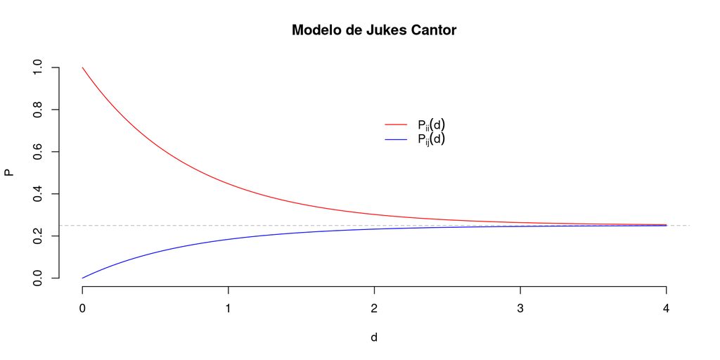

## Otros modelos

[output not shown]

## Tasas variables

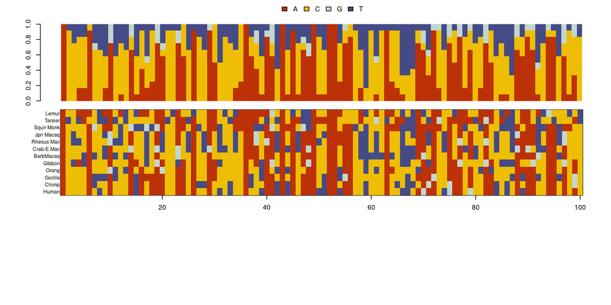

## Tasas variables

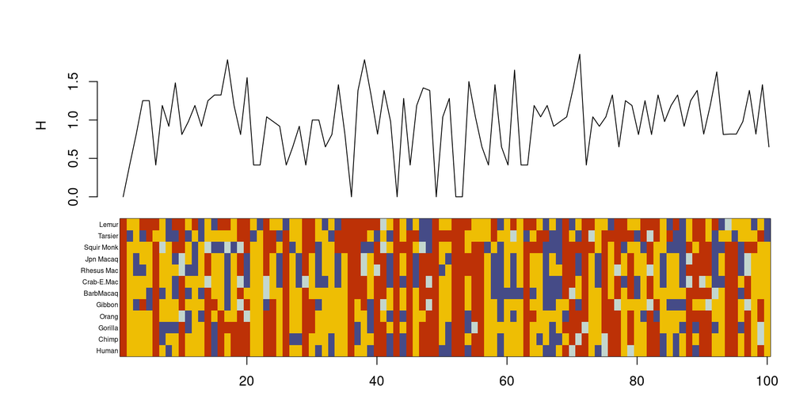

## Tasas variables

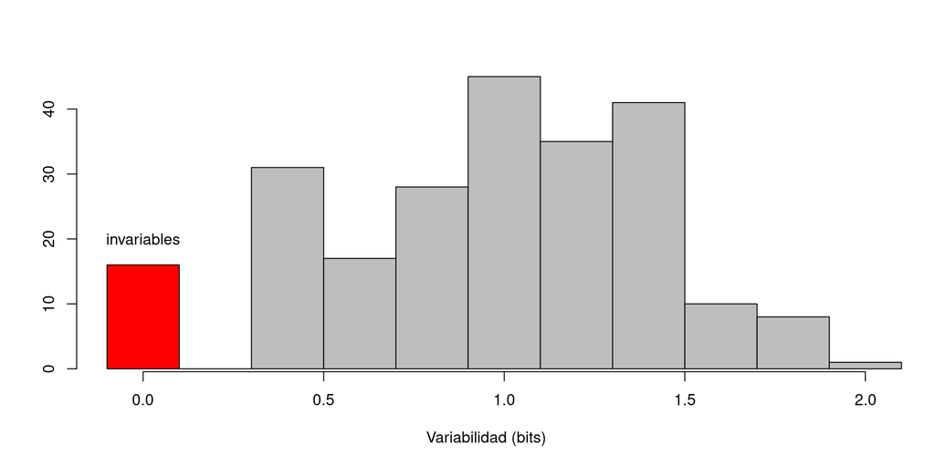

## Distribución Gamma

La variabilidad de la tasa de mutación entre posiciones se modela mediante una distribución Gamma discretizada, con parámetros $\alpha$ = $\beta$, en la que la media es siempre 1 (lo que importa es la varianza, no la media).

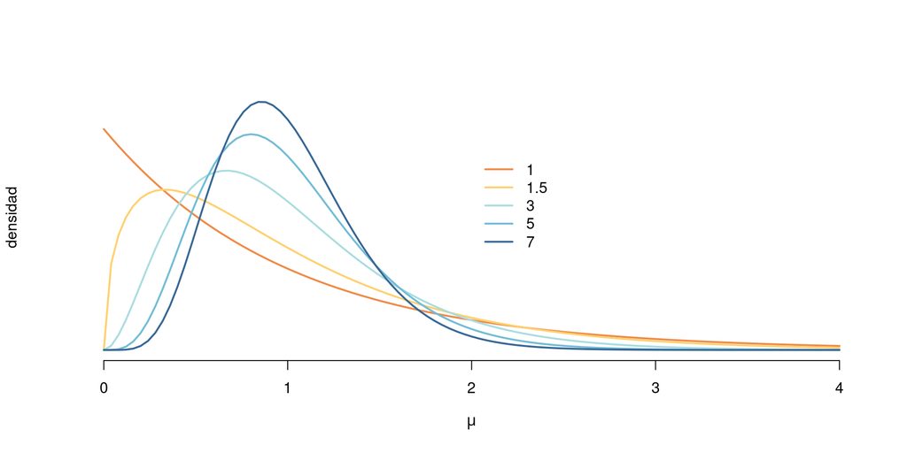

## Discretización de la Gamma

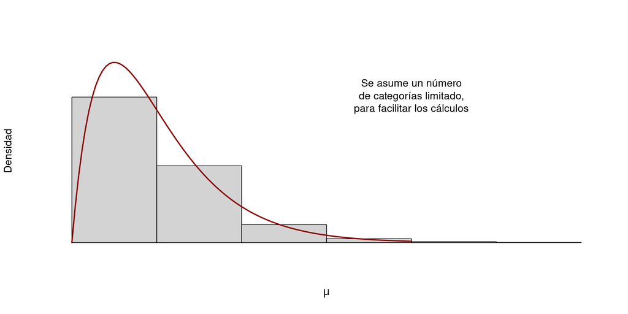

# Los métodos

## Principales métodos

1. Basados en distancias.
2. Máxima parsimonia.
3. Máxima verosimilitud.
4. Bayesianos

# Basados en distancias

## Datos de ejemplo

```r
library(ape)
library(phangorn)
primates <- read.phyDat(system.file('extdata/trees/primates.dna',
                                    package = 'phangorn'),
                        format = 'interleaved')
primates <- subset(primates,
                   subset = names(primates)[! names(primates) %in% c('Mouse', 'Bovine')])
as.StringSet(primates)
```

```
DNAStringSet object of length 12:
     width seq                                              names
 [1]   232 ACCAAACTAACATCTAACAACTA...AAAACTCCATAAACACAAATTC Lemur
 [2]   232 ATCTACCTTATCTCCCCCAATCA...TAAACTCCATAAGTTTGAACAC Tarsier
 [3]   232 ACCCCAGCAACTCGTTGTGACCA...CAAAATACACAATCACCAACAC Squir Monk
 [4]   232 ACTCCACCTGCTCACCTCATCCA...CAAACTGCATAAGCAAACAGAC Jpn Macaq
 [5]   232 ACTTCACCCGTTCACCTCATCCA...CAAACTACATAAACAAACAAAC Rhesus Mac
 ...   ... ...
 [8]   232 ACTATACCCACCCAACTCGACCT...CAACTTACACATACAGAACCAC Gibbon
 [9]   232 ACCCCACCCGTCTACACCAGCCA...AAACCCACACAACCGAAACAAC Orang
[10]   232 ACCCCATTTATCCATAAAAACCA...CAATTCACACAAACAATACCAC Gorilla
[11]   232 ACCCCATCCACCCATACAAACCA...CAATTCACGCAAACAACGCCAC Chimp
[12]   232 ACCCCACTCACCCATACAAACCA...CAATTCGCACACACAACGCCAC Human
```

## Número de diferencias

```
           Lemur Tarsier Squir Monk Jpn Macaq Rhesus Mac Crab-E.Mac BarbMacaq Gibbon Orang Gorilla Chimp
Tarsier      113
Squir Monk   117     132
Jpn Macaq    118     120        117
Rhesus Mac   123     121        120        22
Crab-E.Mac   127     124        115        42         52
BarbMacaq    121     124        114        68         68         66
Gibbon       129     130        105       102         93        104        98
Orang        124     123        109        95         94        103        91     92
Gorilla      117     124        101        93         93        110        98     84    69
Chimp        138     134        115       103        109        115       106     89    78      61
Human        129     136        114        94         94        103       109     83    73      55    52
```

## Proporción de diferencias

```
           Lemur Tarsier Squir Monk Jpn Macaq Rhesus Mac Crab-E.Mac BarbMacaq Gibbon Orang Gorilla Chimp
Tarsier    0.489
Squir Monk 0.506   0.571
Jpn Macaq  0.511   0.519      0.506
Rhesus Mac 0.532   0.524      0.519     0.095
Crab-E.Mac 0.550   0.537      0.498     0.182      0.225
BarbMacaq  0.524   0.537      0.494     0.294      0.294      0.286
Gibbon     0.558   0.563      0.455     0.442      0.403      0.450     0.424
Orang      0.537   0.532      0.472     0.411      0.407      0.446     0.394  0.398
Gorilla    0.506   0.537      0.437     0.403      0.403      0.476     0.424  0.364 0.299
Chimp      0.597   0.580      0.498     0.446      0.472      0.498     0.459  0.385 0.338   0.264
Human      0.558   0.589      0.494     0.407      0.407      0.446     0.472  0.359 0.316   0.238 0.225
```

## Distancias Jukes Cantor

La probabilidad de que un nucleótido sea diferente al ancestral en una secuencia bajo este modelo es $3\times p_{ij}(t)$:

$$\hat{d} = -\frac{3}{4}\log\left(1 - \frac{4}{3}\hat{p}\right)$$

## Distancias Jukes Cantor

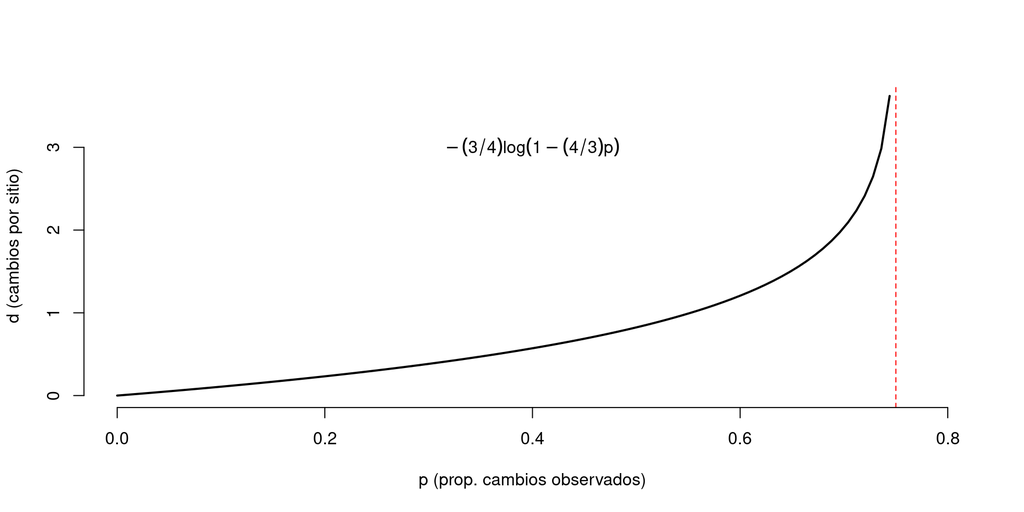

## Distancias Jukes Cantor

```
           Lemur Tarsier Squir Monk Jpn Macaq Rhesus Mac Crab-E.Mac BarbMacaq Gibbon Orang Gorilla Chimp
Tarsier    0.792
Squir Monk 0.844   1.076
Jpn Macaq  0.857   0.885      0.844
Rhesus Mac 0.928   0.899      0.885     0.102
Crab-E.Mac 0.991   0.943      0.817     0.208      0.268
BarbMacaq  0.899   0.943      0.805     0.374      0.374      0.360
Gibbon     1.024   1.041      0.699     0.666      0.577      0.688     0.625
Orang      0.943   0.928      0.744     0.596      0.587      0.677     0.559  0.568
Gorilla    0.844   0.943      0.656     0.577      0.577      0.756     0.625  0.497 0.381
Chimp      1.194   1.114      0.817     0.677      0.744      0.817     0.710  0.541 0.449   0.326
Human      1.024   1.153      0.805     0.587      0.587      0.677     0.744  0.489 0.410   0.286 0.268
```

## Distancias Kimura 1980

```
           Lemur Tarsier Squir Monk Jpn Macaq Rhesus Mac Crab-E.Mac BarbMacaq Gibbon Orang Gorilla Chimp
Tarsier    0.794
Squir Monk 0.852   1.088
Jpn Macaq  0.869   0.899      0.931
Rhesus Mac 0.950   0.912      0.990     0.105
Crab-E.Mac 1.029   0.973      0.886     0.222      0.296
BarbMacaq  0.915   0.965      0.867     0.430      0.432      0.413
Gibbon     1.029   1.064      0.717     0.725      0.604      0.751     0.665
Orang      0.969   0.932      0.770     0.646      0.630      0.759     0.588  0.614
Gorilla    0.848   0.953      0.678     0.614      0.612      0.875     0.676  0.544 0.409
Chimp      1.272   1.151      0.875     0.754      0.855      0.989     0.799  0.604 0.497   0.366
Human      1.044   1.204      0.857     0.627      0.624      0.749     0.855  0.532 0.442   0.316 0.296
```

## Distancias Felsenstein 1981

```
           Lemur Tarsier Squir Monk Jpn Macaq Rhesus Mac Crab-E.Mac BarbMacaq Gibbon Orang Gorilla Chimp
Tarsier    0.889
Squir Monk 0.959   1.318
Jpn Macaq  0.978   1.017      0.959
Rhesus Mac 1.080   1.038      1.017     0.103
Crab-E.Mac 1.176   1.103      0.923     0.213      0.275
BarbMacaq  1.038   1.103      0.906     0.389      0.389      0.374
Gibbon     1.229   1.257      0.768     0.728      0.620      0.755     0.678
Orang      1.103   1.080      0.826     0.643      0.631      0.741     0.599  0.609
Gorilla    0.959   1.103      0.715     0.620      0.620      0.841     0.678  0.528 0.397
Chimp      1.542   1.384      0.923     0.741      0.826      0.923     0.782  0.578 0.472   0.337
Human      1.229   1.458      0.906     0.631      0.631      0.741     0.826  0.518 0.430   0.295 0.275
```

## Distancias Tamura 1992

```
           Lemur Tarsier Squir Monk Jpn Macaq Rhesus Mac Crab-E.Mac BarbMacaq Gibbon Orang Gorilla Chimp
Tarsier    0.796
Squir Monk 0.854   1.092
Jpn Macaq  0.872   0.902      0.937
Rhesus Mac 0.954   0.916      0.998     0.105
Crab-E.Mac 1.034   0.978      0.891     0.223      0.296
BarbMacaq  0.919   0.969      0.872     0.432      0.434      0.414
Gibbon     1.033   1.070      0.720     0.729      0.605      0.755     0.668
Orang      0.973   0.935      0.773     0.649      0.632      0.764     0.590  0.617
Gorilla    0.851   0.956      0.680     0.617      0.614      0.882     0.679  0.546 0.410
Chimp      1.283   1.158      0.880     0.758      0.861      0.999     0.804  0.607 0.499   0.368
Human      1.048   1.212      0.861     0.629      0.626      0.753     0.861  0.534 0.443   0.317 0.296
```

## Neighbor-joining

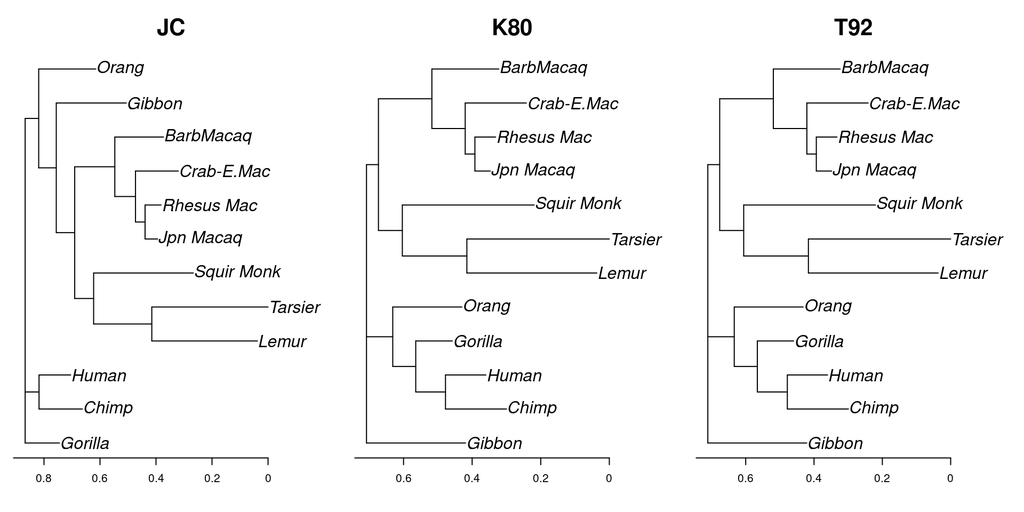

## UPGMA

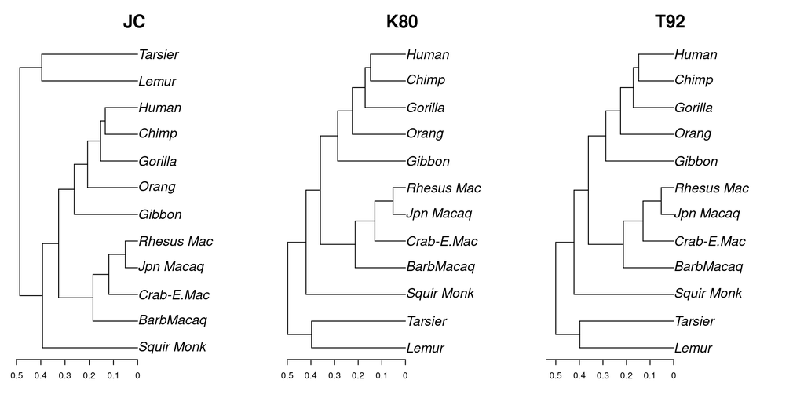

### Neighbor-joining

- Árboles no enraizados.
- Cada linaje con una cantidad de cambios.
- Longitudes de ramas reflejan bien las distancias.

### UPGMA

- Árboles enraizados.
- Asume reloj molecular: árboles ultramétricos.
- Longitudes de ramas menos fieles a las distancias.

# Bootstrap

## Definición

El **bootstrap** és un método para evaluar el error con el que estimamos un estadístico cuando sólo disponemos de una muestra. Consiste en generar *pseudo-réplicas* de la muestra, re-calcular el estadístico varias veces y ver cuánto se diferencian. Por ejemplo:

```r
muestra <- round(rnorm(20, mean = 172, sd = 5), 2)
estadistico <- mean(muestra)
# Re-muestreamos la muestra con repetición 200 veces: 10 pseudo-muestras.
pseudoreplicas <- matrix(sample(muestra, 200, replace = TRUE), ncol = 10)
# Valores de bootstrap:
apply(pseudoreplicas, 2, mean)
```

```
 [1] 173.0495 173.2215 174.1760 172.6265 173.9025 171.9005 173.0535 174.0090 172.8435 174.9020
```

## Ejemplo gráfico

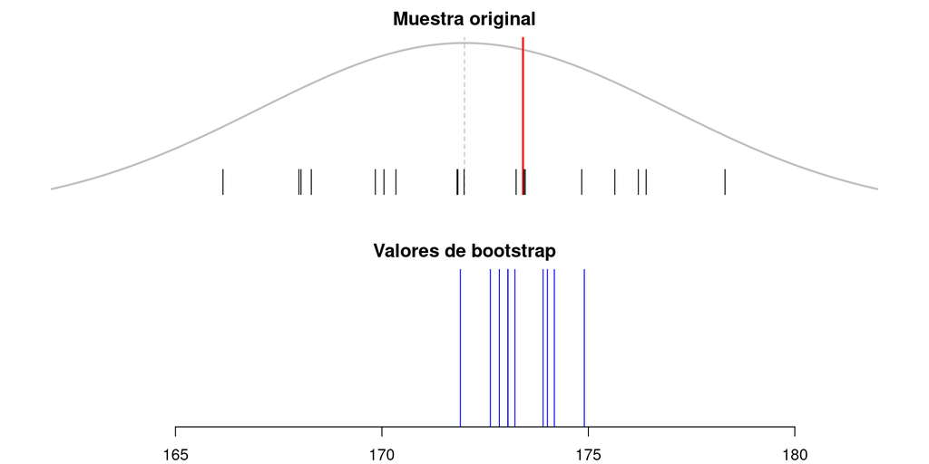

## En filogenias

1. Muestrear las posiciones del alineamiento con repetición.
2. Repetir la reconstrucción filogenética.
3. Contar la proporción de veces en que se observa cada rama en las réplicas.

```r
arbol <- NJ(dist.ml(primates))
bs_nj <- bootstrap.phyDat(primates, bs = 100,
                          FUN = function(x) NJ(dist.ml(primates)))
plotBS(arbol, bs_nj, main = 'NJ', bs.adj = c(2, 1.5))
```

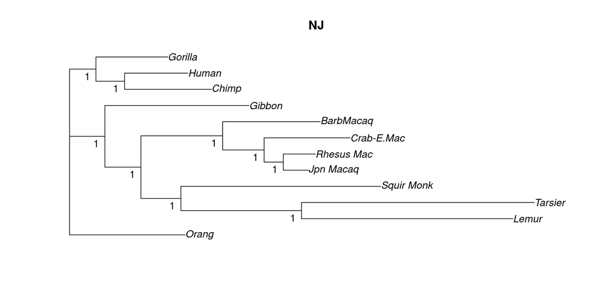

# Máxima verosimilitud

## Definición

$$L(M)\propto P(D|M)$$

La *verosimilitud* es una función del modelo ($M$) o hipótesis. Es igual (o al menos proporcional) a la probabilidad de los datos ($D$) cuando la hipótesis es cierta.

## La probabilidad de los datos

El árbol y el modelo de evolución molecular permiten calcular la probabilidad de las bases observadas en cada posición $i$ (Felsenstein 1981):

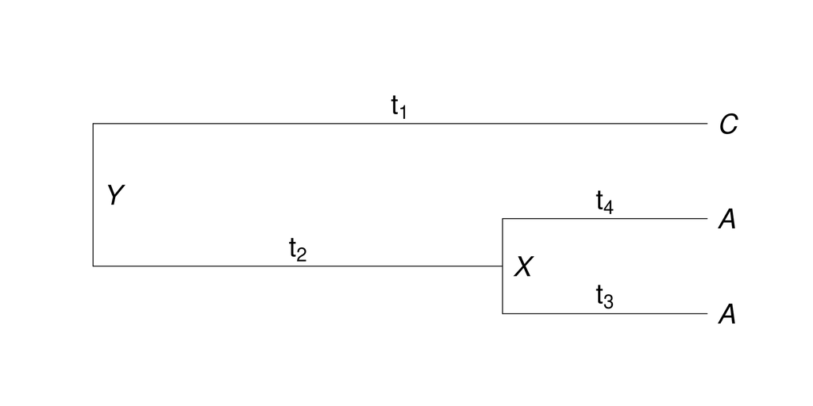

$$L_i(M) = \sum_Y \pi_Y p_{YC}(t_1)\cdot \left(\sum_X p_{YX}(t_2)p_{XA}(t_3)p_{XA}(t_4)\right)$$

## Con tasas variables

Si asumimos que las tasas de cambio varían entre posiciones de acuerdo a una distribución Gamma con parámetros $\alpha$ y $\beta = \alpha$, y aproximamos la distribución Gamma con $k$ categorías, cuyas tasas de cambio medias sean $r_1, r_2... r_k$, entonces:

$$L_i(M) = \sum_{j=1}^k P(r_j)\cdot L_i(r_j)$$

Donde $L_i(r_j)$ es la verosimilitud del modelo en el sitio $i$ asumiendo unas longitudes de rama multiplicadas por $r_j$.

## Independencia y logaritmos

Asumiendo independencia entre posiciones:

$$L(M) = \prod_i L_i(M) \\
\log(L(M)) = \sum_i \log(L_i(M))$$

Los logaritmos permiten trabajar en una escala mucho más cómoda y convierten las multiplicaciones en sumas.

## Procedimiento

1. Selección del modelo de evolución molecular más adecuado.
2. Búsqueda repetida de árboles más verosímiles:
   - Generación estocástica de topologías diferentes.
   - Optimización de las longitudes de rama.
3. Selección de los árboles (no enraizados!) más verosímiles.

## Principales programas

1. [RAxML](https://github.com/amkozlov/raxml-ng) (Stamatakis 2014). Destaca su rapidez.
2. [IQ-tree](https://iqtree.github.io/) (Minh et al. 2025). Más versátil y fácil de aprender.
3. [phangorn](https://cran.r-project.org/web/packages/phangorn/index.html) (Schliep 2010). Es un paquete de R.
4. [PAUP*](https://paup.phylosolutions.com/) (Swofford 2003). Programa clásico para máxima parsimonia, pero que también aplica máxima verosimilitud.

# [Ejemplo](https://cran.r-project.org/web/packages/phangorn/vignettes/Trees.html)

## Selección de modelo

```r
mt <- modelTest(primates, G = TRUE, I = TRUE, k = 4)
```

[output not shown]

| Model | df | logLik | AIC | AICc | BIC |
| --- | --- | --- | --- | --- | --- |
| TrN+G(4) | 27 | -2128.577 | 4311.154 | 4318.565 | 4404.215 |
| TIM2+G(4) | 28 | -2128.384 | 4312.768 | 4320.768 | 4409.277 |
| TrN+G(4)+I | 28 | -2128.426 | 4312.851 | 4320.851 | 4409.360 |
| TIM1+G(4) | 28 | -2128.476 | 4312.952 | 4320.952 | 4409.460 |
| TIM3+G(4) | 28 | -2128.573 | 4313.145 | 4321.145 | 4409.654 |
| TIM2+G(4)+I | 29 | -2128.241 | 4314.482 | 4323.096 | 4414.437 |
| TIM1+G(4)+I | 29 | -2128.320 | 4314.639 | 4323.253 | 4414.595 |
| TIM3+G(4)+I | 29 | -2128.418 | 4314.836 | 4323.450 | 4414.791 |
| TrN | 26 | -2132.316 | 4316.631 | 4323.480 | 4406.246 |
| TrN+I | 27 | -2131.312 | 4316.624 | 4324.036 | 4409.686 |
| TIM2 | 27 | -2132.078 | 4318.156 | 4325.568 | 4411.218 |
| TIM1 | 27 | -2132.102 | 4318.204 | 4325.616 | 4411.266 |
| GTR+G(4) | 30 | -2128.221 | 4316.441 | 4325.695 | 4419.843 |
| TIM3 | 27 | -2132.316 | 4318.632 | 4326.044 | 4411.694 |
| TIM2+I | 28 | -2131.087 | 4318.173 | 4326.173 | 4414.682 |
| TIM1+I | 28 | -2131.137 | 4318.275 | 4326.275 | 4414.783 |
| TIM3+I | 28 | -2131.318 | 4318.635 | 4326.635 | 4415.144 |
| GTR+G(4)+I | 31 | -2128.074 | 4318.148 | 4328.068 | 4424.997 |
| GTR | 29 | -2131.690 | 4321.381 | 4329.994 | 4421.336 |
| GTR+I | 30 | -2130.770 | 4321.540 | 4330.794 | 4424.943 |
| HKY+G(4) | 26 | -2135.991 | 4323.983 | 4330.832 | 4413.598 |
| TPM2u+G(4) | 27 | -2135.850 | 4325.700 | 4333.112 | 4418.762 |
| TPM1u+G(4) | 27 | -2135.872 | 4325.744 | 4333.156 | 4418.806 |
| HKY+G(4)+I | 27 | -2135.960 | 4325.920 | 4333.331 | 4418.982 |
| TPM3u+G(4) | 27 | -2135.992 | 4325.984 | 4333.395 | 4419.045 |
| TPM2u+G(4)+I | 28 | -2135.814 | 4327.628 | 4335.628 | 4424.137 |
| TPM1u+G(4)+I | 28 | -2135.840 | 4327.681 | 4335.681 | 4424.190 |
| TPM3u+G(4)+I | 28 | -2135.960 | 4327.920 | 4335.920 | 4424.429 |
| HKY | 25 | -2140.426 | 4330.851 | 4337.162 | 4417.020 |
| TVM+G(4) | 29 | -2135.501 | 4329.001 | 4337.615 | 4428.957 |

[output cut: 62 more lines]

## Selección del modelo

El objeto de clase `modeltest` es un marco de datos con información adicional escondida sobre los modelos que ha comparado y las secuencias. Podemos recuperar un modelo ajustado indicando su nombre o el criterio para escogerlo:

```r
fit <- as.pml(mt, 'BIC')
print(fit)
```

```
model: TrN+G(4)
loglikelihood: -2128.577
unconstrained loglikelihood: -1230.335
Model of rate heterogeneity: Discrete gamma model
Number of rate categories: 4
Shape parameter: 7.353348
       Rate Proportion
1 0.5777386       0.25
2 0.8448532       0.25
3 1.0781309       0.25
4 1.4992772       0.25

Rate matrix:
         a        c        g        t
a   0.0000  1.00000 125.3146  1.00000
c   1.0000  0.00000   1.0000 44.88449
g 125.3146  1.00000   0.0000  1.00000
t   1.0000 44.88449   1.0000  0.00000

Base frequencies:
         a          c          g          t
0.36363636 0.41394179 0.04096299 0.18145886
```

## Optimización

La selección de modelo se realizó asumiendo un árbol concreto (NJ). La función `pml_bb()` parte de ese árbol y del modelo escogido para buscar árboles y valores de parámetros más verosímiles:

```r
fit_mt <- pml_bb(mt)
```

También se puede buscar el mejor árbol especificando el alineamiento y el modelo:

```r
fit_mt <- pml_bb(primates, model = 'TrN+G(4)')
```

Se pueden controlar los detalles de la optimización con la función `pml.control()`:

```r
fit_mt <- pml_bb(mt, control = pml.control(statefreq = 'estimate', maxit = 50))
```

## Resultados

```r
print(fit_mt)
```

```
model: TrN+G(4)
loglikelihood: -2129.403
unconstrained loglikelihood: -1230.335
Model of rate heterogeneity: Discrete gamma model
Number of rate categories: 4
Shape parameter: 5.752208
       Rate Proportion
1 0.5306073       0.25
2 0.8200103       0.25
3 1.0818049       0.25
4 1.5675775       0.25

Rate matrix:
         a        c        g        t
a  0.00000  1.00000 89.56178  1.00000
c  1.00000  0.00000  1.00000 34.53677
g 89.56178  1.00000  0.00000  1.00000
t  1.00000 34.53677  1.00000  0.00000

Base frequencies:
         a          c          g          t
0.36363636 0.41394179 0.04096299 0.18145886
```

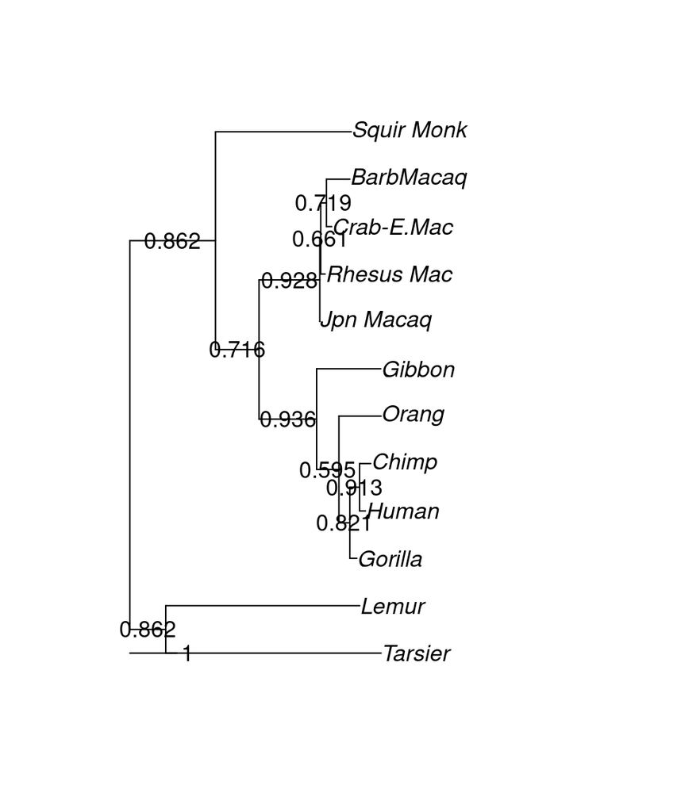

```r
plot(fit_mt)
```

## Bootstrap

`pml_bb()` aplica por defecto el *bootstrap* (si `rearrangements = 'stochastic'`). Podemos también generar las réplicas de *bootstrap* separadamente:

```r
bs <- bootstrap.pml(fit_mt, bs=100, optNni=TRUE,
    control = pml.control(trace = 0))
plotBS(midpoint(fit_mt$tree), bs, digits = 3)
```

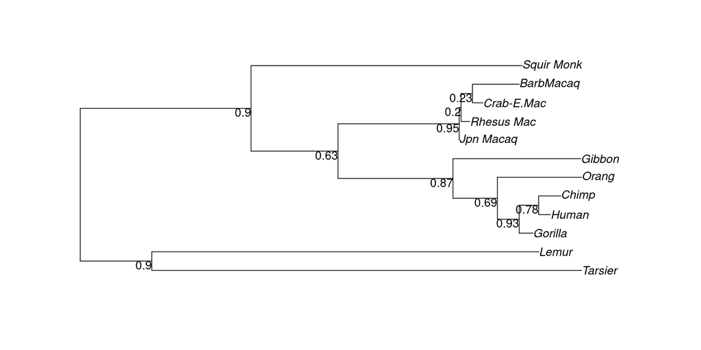

# Inferencia Bayesiana

## Teorema de Bayes

$$P(M|D) = \frac{P(D|M)\cdot P(M)}{P(D)}$$
$P(M|D)$ es la probabilidad **posterior** del modelo (después de haber visto los datos); $P(M)$ es la probabilidad **a priori** (o *prior*) del modelo (o hipótesis); $P(D|M)$ es la verosimilitud; y $P(D)$ es la probabilidad total de los datos o *evidencia*.

## Inferencia Bayesiana

1. Decidir los *priors* de cada parámetro del modelo: topología del árbol, longitudes de ramas, parámetros del modelo de evolución molecular…
2. Construir una cadena de Markov en la que todos los parámetros van tomando nuevos valores, de tal manera que…
3. …la distribución estacionaria conjunta de los parámetros es precisamente la **distribución posterior**.
4. Se toma una muestra suficiente de la distribución posterior para saber qué topologías y qué valores de los parámetros son los más probables a posteriori.

## Markov Chain Monte Carlo

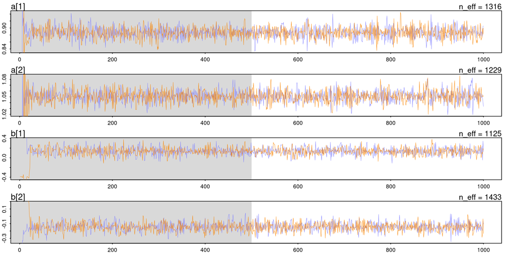

## Principales programas

1. [MrBayes](https://nbisweden.github.io/MrBayes/) (Ronquist et al. 2012).
2. [RevBayes](https://revbayes.github.io/) (Höhna et al. 2016). El que yo recomiendo.
3. [BEAST2](https://www.beast2.org/citation/) (Bouckaert 2019).

## Referencias

Bouckaert, Timothy G. AND Barido-Sottani, Remco AND Vaughan. 2019. “BEAST 2.5: An Advanced Software Platform for Bayesian Evolutionary Analysis.” *PLOS Computational Biology* 15 (4): 1–28. https://doi.org/10.1371/journal.pcbi.1006650.

Durbin, R., S. Eddy, A. Krogh, and G. Mitchison. 1998. *Biological Sequence Analysis; Probabilistic Models of Proteins and Nucleic Acids*. Cambridge University Press.

Felsenstein, J. 1981. “Evolutionary Trees from DNA Sequences: A Maximum Likelihood Approach.” *Journal of Molecular Evolution* 17: 368–76.

Höhna, Sebastian, Michael J. Landis, Tracy A. Heath, Bastien Boussau, Nicolas Lartillot, Brian R. Moore, John P. Huelsenbeck, and Fredrik Ronquist. 2016. “RevBayes: Bayesian Phylogenetic Inference Using Graphical Models and an Interactive Model-Specification Language.” *Systematic Biology* 65 (4): 726–36. https://doi.org/10.1093/sysbio/syw021.

Minh, B. Q., H. A. Schmidt, O. Chernomor, D. Schrempf, M. D. Woodhams, and A. von Haeseler. 2025. “IQ-TREE 3: Phylogenomic Inference Software Using Complex Evolutionary Models.” *EcoEvoRxiv*. https://doi.org/10.32942/X2S690.

Ronquist, Fredrik, Maxim Teslenko, Paul van der Mark, Daniel L. Ayres, Aaron Darling, Sebastian Höhna, Bret Larget, Liang Liu, Marc A. Suchard, and John P. Huelsenbeck. 2012. “MrBayes 3.2: Efficient Bayesian Phylogenetic Inference and Model Choice Across a Large Model Space.” *Systematic Biology* 61 (3): 539–42. https://doi.org/10.1093/sysbio/sys029.

Schliep, K. P. 2010. “Phangorn: Phylogenetic Analysis in r.” *Bioinformatics* 27 (4): 592–93. https://doi.org/10.1093/bioinformatics/btq706.

Stamatakis, A. 2014. “RAxML Version 8: A Tool for Phylogenetic Analysis and Post-Analysis of Large Phylogenies.” *Bioinformatics* 30 (9): 1312–13. https://doi.org/10.1093/bioinformatics/btu033.

Swofford, D. L. 2003. *PAUP*: Phylogenetic Analysis Using Parsimony (*and Other Methods). Version 4*. Sunderland, Massachusetts: Sinauer Associates. https://paup.phylosolutions.com/.

Yang, Z. 2006. *Computational Molecular Evolution*. Oxford: Oxford University Press.

Zou, Y., Z. Zhang, Y. Zeng, H. Hu, Y. Hao, S. Huang, and B. Li. 2024. “Common Methods for Phylogenetic Tree Construction and Their Implementation in r.” *Bioengineering* 11 (5). https://doi.org/10.3390/bioengineering11050480.